# 20201108-p8133_probset12_jsg2145

Jared Garfinkel

11/8/2020

# Problem 12

Calculate the distribution of B using a randomized PTW design.

The first trial has equal probabilities of each treatment.

## P(tr_0)

P(A) = P(B) = 0.5

## P(tr_1)

However, the probability of the next trial depends on the outcome of the first. So,

$p(tr_1 = A|tr_0 = A_{success}) = 2/3 * 0.2 / 2$

$p(tr_1 = A|tr_0 = A_{failure}) = 1/3 * 0.8 / 2$

$p(tr_1 = A|tr_0 = B_{success}) = 1/3 * 0.8 / 2$

$p(tr_1 = A|tr_0 = B_{failure}) = 2/3 * 0.2 / 2$

$p(tr_1 = A)$ = 0.4

$p(tr_1 = B|tr_0 = A_{success}) = 1/3 * 0.2 / 2$

$p(tr_1 = B|tr_0 = A_{failure}) = 2/3 * 0.8 / 2$

$p(tr_1 = B|tr_0 = B_{success}) = 2/3 * 0.8 / 2$

$p(tr_1 = B|tr_0 = B_{failure}) = 1/3 * 0.2 / 2$

$p(tr_1 = B)$ = 0.6

## P(tr_2)

$p(tr_2 = A|tr_x = (A_{success}, A_{success})) = 0.5 * 2/3 * 0.2 * 0.2 * 3/4$

$p(tr_2 = A|tr_x = (A_{success}, A_{failure})) = 0.5 * 2/3 * 0.2 * 0.8 * 2/4$

$p(tr_2 = A|tr_x = (A_{failure}, A_{success})) = 0.5 * 1/3 * 0.2 * 0.8 * 2/4$

$p(tr_2 = A|tr_x = (A_{failure}, A_{failure})) = 0.5 * 1/3 * 0.8 * 0.8 * 1/4$

$p(tr_2 = A|tr_x = (A_{success}, B_{failure})) = 0.5 * 1/3 * 0.2 * 0.2 * 3/4$

$p(tr_2 = A|tr_x = (A_{success}, B_{success})) = 0.5 * 1/3 * 0.2 * 0.8 * 2/4$

$p(tr_2 = A|tr_x = (A_{failure}, B_{failure})) = 0.5 * 2/3 * 0.8 * 0.2 * 2/4$

$p(tr_2 = A|tr_x = (A_{failure}, B_{success})) = 0.5 * 2/3 * 0.8 * 0.8 * 1/4$

$p(tr_2 = A|tr_x = (B_{success}, A_{success})) = 0.5 * 1/3 * 0.8 * 0.2 * 2/4$

$p(tr_2 = A|tr_x = (B_{success}, A_{failure})) = 0.5 * 1/3 * 0.8 * 0.8 * 1/4$

$p(tr_2 = A|tr_x = (B_{failure}, A_{success})) = 0.5 * 2/3 * 0.2 * 0.2 * 3/4$

$p(tr_2 = A|tr_x = (B_{failure}, A_{failure})) = 0.5 * 2/3 * 0.2 * 0.8 * 2/4$

$p(tr_2 = A|tr_x = (B_{success}, B_{failure})) = 0.5 * 2/3 * 0.8 * 0.2 * 2/4$

$p(tr_2 = A|tr_x = (B_{success}, B_{success})) = 0.5 * 2/3 * 0.8 * 0.8 * 1/4$

$p(tr_2 = A|tr_x = (B_{failure}, B_{failure})) = 0.5 * 1/3 * 0.2 * 0.2 * 3/4$

$p(tr_2 = A|tr_x = (B_{failure}, B_{success})) = 0.5 * 1/3 * 0.2 * 0.8 * 2/4$

$p(tr_2 = A)$ = 0.35

$p(tr_2 = B|tr_x = (A_{success}, A_{success})) = 0.5 * 2/3 * 0.2 * 0.2 * 1/4$

$p(tr_2 = B|tr_x = (A_{success}, A_{failure})) = 0.5 * 2/3 * 0.2 * 0.8 * 2/4$

$p(tr_2 = B|tr_x = (A_{failure}, A_{success})) = 0.5 * 1/3 * 0.2 * 0.8 * 2/4$

$p(tr_2 = B|tr_x = (A_{failure}, A_{failure})) = 0.5 * 1/3 * 0.8 * 0.8 * 3/4$

$p(tr_2 = B|tr_x = (A_{success}, B_{failure})) = 0.5 * 1/3 * 0.2 * 0.2 * 1/4$

$p(tr_2 = B|tr_x = (A_{success}, B_{success})) = 0.5 * 1/3 * 0.2 * 0.8 * 2/4$

$p(tr_2 = B|tr_x = (A_{failure}, B_{failure})) = 0.5 * 2/3 * 0.8 * 0.2 * 2/4$

$p(tr_2 = B|tr_x = (A_{failure}, B_{success})) = 0.5 * 2/3 * 0.8 * 0.8 * 3/4$

$p(tr_2 = B|tr_x = (B_{success}, A_{success})) = 0.5 * 1/3 * 0.8 * 0.2 * 2/4$

$p(tr_2 = B|tr_x = (B_{success}, A_{failure})) = 0.5 * 1/3 * 0.8 * 0.8 * 3/4$

$p(tr_2 = B|tr_x = (B_{failure}, A_{success})) = 0.5 * 2/3 * 0.2 * 0.2 * 1/4$

$p(tr_2 = B|tr_x = (B_{failure}, A_{failure})) = 0.5 * 2/3 * 0.2 * 0.8 * 2/4$

$p(tr_2 = B|tr_x = (B_{success}, B_{failure})) = 0.5 * 2/3 * 0.8 * 0.2 * 2/4$

$p(tr_2 = B|tr_x = (B_{success}, B_{success})) = 0.5 * 2/3 * 0.8 * 0.8 * 3/4$

$p(tr_2 = B|tr_x = (B_{failure}, B_{failure})) = 0.5 * 1/3 * 0.2 * 0.2 * 1/4$

$p(tr_2 = B|tr_x = (B_{failure}, B_{success})) = 0.5 * 1/3 * 0.2 * 0.8 * 2/4$

$p(tr_2 = B)$ = 0.65

```r
urn = c(0, 1) %>%
  tibble() %>%
  rename("urn" = ".")
```

```r
tr_0 = sample_n(urn, 1)
```

```r
addaball = function(df = urn, tr = tr_0, pra = 0.2, prb = 0.8) {
  if (pull(tr, urn) == 0) {
    outcome = rbinom(1, 1, pra)
    if (outcome == 0) {
      df = df %>%
        add_row(urn = 1)
    }
    else {
      df = df %>%
        add_row(urn = 0)
    }
  }
  if (pull(tr, urn) == 1) {
    outcome = rbinom(1, 1, prb)
    if (outcome == 0) {
      df = df %>%
        add_row(urn = 0)
    }
    else {
      df = df %>%
        add_row(urn = 1)
    }
  }
  return(df)
}
```

```r
pickaball = function(df = urn, func = addaball, tr, pra, prb) {
  tr_0 = sample_n(df, 1)
  urn1 = func(df, tr, pra = pra, prb = prb)
  tr_1 = sample_n(urn1, 1)
  urn2 = func(df = urn1, tr = tr_1, pra = pra, prb = prb)
  tr_2 = sample_n(urn2, 1)
  urn3 = func(df = urn2, tr = tr_2, pra = pra, prb = prb)
  tr_3 = sample_n(urn3, 1)
  res = rbind(tr_0, tr_1, tr_2, tr_3) %>%
    rename("treatment" = "urn")
  return(res)
}
```

```r
sim = function(n = 10, df = urn, func = addaball, tr = tr_0, pra = 0.2, prb = 0.8) {
  set.seed(719)
  output = rerun(n, pickaball(df, func, tr, pra, prb))

  for (i in 1:length(output)) {
    output[[i]] = output[[i]] %>%
      add_column("trial" = i)
  }

  nested_output = output %>%
    bind_rows() %>%
    nest(-trial)

  dist_df = nested_output %>%
    mutate(data = map(data, sum))

  return(dist_df)
}
```

```r
dist_df = sim(n = 5000)
```

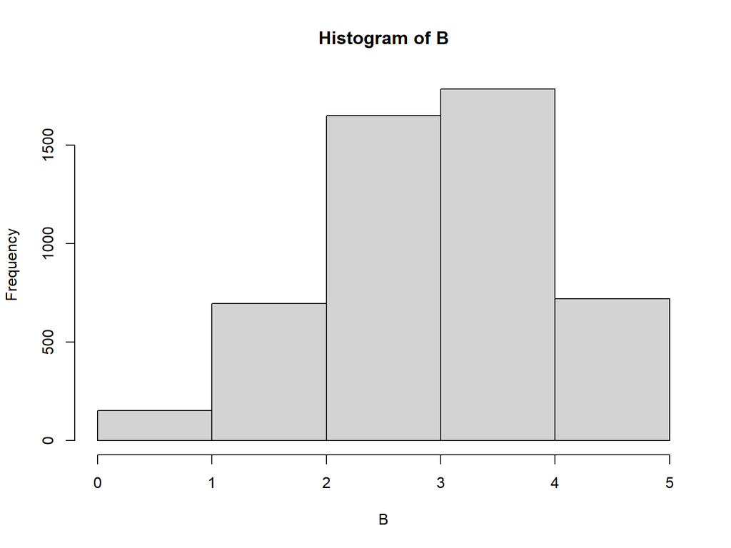

```r
dist_df %>%
  unnest(cols = c(data)) %>%
  pull(data) %>%
  hist(right = FALSE, breaks = c(0:5), main = "Histogram of B", xlab = "B")
```

A simulation shows the distribution of outcomes of treatment B.

```r
exp_df = dist_df %>%
  unnest(cols = c(data)) %>%
  count(data) %>%
  group_by(data) %>%
  mutate(B = n/5000)
```

The expected value can be estimated as 2.4446.

### Part b

```r
dist_df2 = sim(n = 5000, pra = 0.3, prb = 0.3)
```

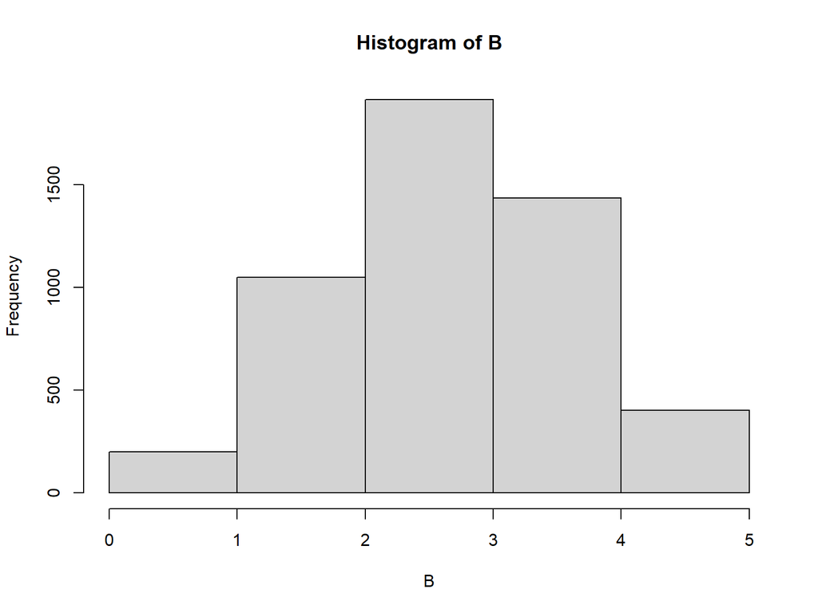

```r
dist_df2 %>%
  unnest(cols = c(data)) %>%
  pull(data) %>%
  hist(right = FALSE, breaks = c(0:5), main = "Histogram of B", xlab = "B")
```

```r
exp_df2 = dist_df2 %>%
  unnest(cols = c(data)) %>%
  count(data) %>%
  group_by(data) %>%
  mutate(B = n/5000)
```

The expected value can be estimated as 2.158.